# Plotting Multivariable Functions in R

# Introduction

This notebook will use the function plotFun from the mosaic package. If necessary, being by installing the mosaic package. Next, load the mosaic package with the command

```r
library(mosaic)
```

We will introduce the functionality of plotFun by plotting some single-variable functions familiar from calulus I and II. Then, we will use the same function to plot some functions of two variable beginning with two-variable linear functions.

# Quick Review of Single Variable Plots

Let’s plot the linear function $y=-2x + 4$ in R using plotFun:

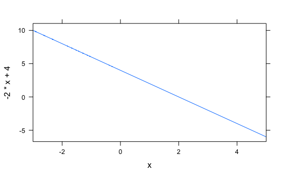

```r
plotFun(-2*x+4~x,x.lim=range(-3,5))
```

Let’s plot $f(x) = -2x^2 + 6x - 3$:

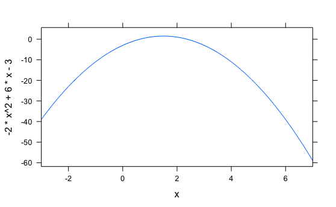

```r
plotFun(-2*x^2+6*x - 3~x,x.lim=range(-3,7))
```

It’s not a very big adjustment to obtain a graph for a function of two variables. We will demonstrate this initially with two variable linear graphs which as discussed are planes in three-dimensional space.

# Two-variable Linear Functions.

Recall that a two-variable linear function has the form

$F(x_{1},x_{2}) = m_{1}x_{1} + m_{2}x_{2} + b$

Let’s look at the example from the notes:

$F(x_{1},x_{2}) = -2x_{1} + 3x_{2} + 1$

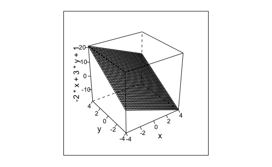

```r
plotFun(-2*x + 3*y + 1 ~ x & y,x.lim=range(-4,4),y.lim=range(-4,4),surface = TRUE)
```

If we run this command in the console rather than in a notebook, we are able to manipulate the plot. Let’s try this.

What happens if we do not include the optional argument surface=TRUE? Let’s investigate this.

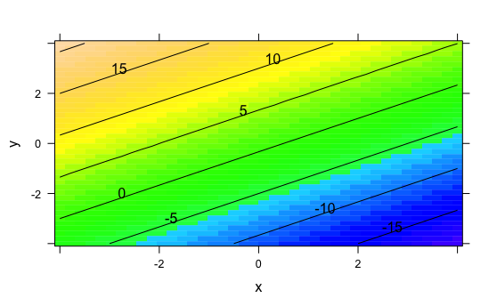

```r
plotFun(-2*x + 3*y + 1 ~ x & y,x.lim=range(-4,4),y.lim=range(-4,4))
```

In order to see the results it is necessary to run this command in the console.

We get what is known as a contour plot. Such a plot shows the curves (which in this case are lines) of constant elevation.

Let’s look at another example. Consider the linear two-variable function $F(x_{1},x_{2}) = 5x_{1} - 3x_{2} - 2$. We start by turning this into an R function which is not necessary but will be useful for the pruposes of illustrating certain points.

```r
F <- makeFun(5*x - 3*y - 2 ~ x & y)
```

Now let’s plot the corresponding plane:

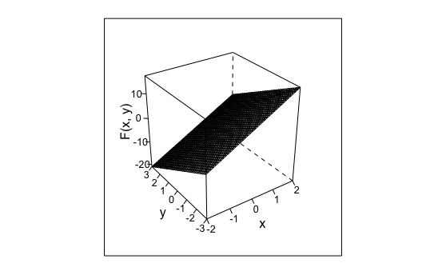

```r
plotFun(F(x,y)~x&y,x.lim = range(-2,2),y.lim=range(-3,3),surface = TRUE)
```

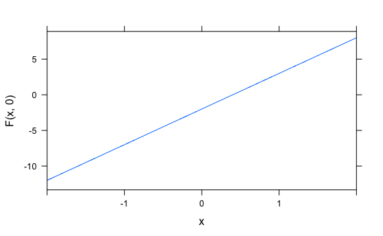

```r
plotFun(F(x,0)~x,x.lim = range(-2,2))
```

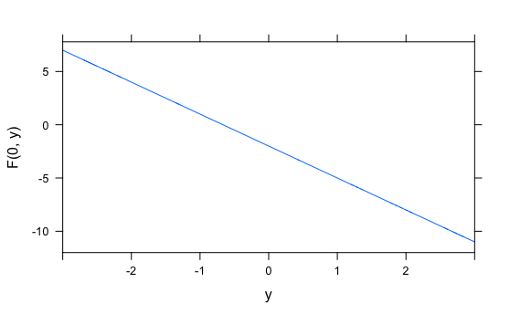

```r
plotFun(F(0,y)~y,y.lim=range(-3,3))
```

Let’s make a contour plot for this function by pasting the following command into the console.

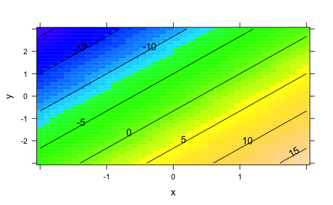

```r
plotFun(F(x,y)~x&y,x.lim = range(-2,2),y.lim=range(-3,3))
```

# More General Two-variable Functions.

Consider the following function:

$F(x_{1},x_{2}) = 2x_{1}^2 + 4x_{2}^{2} + 7$

We can easily use plotFun to graph the surface corresponding to the graph of $F(x_{1},x_{2}) = 2x_{1}^2 + 4x_{2}^{2} + 7$. First we create an R function corresponding to two-variable function currently under consideration.

```r
F <- makeFun(2*x^2+4*y^2+7 ~ x & y)
```

Now we will plot the surface

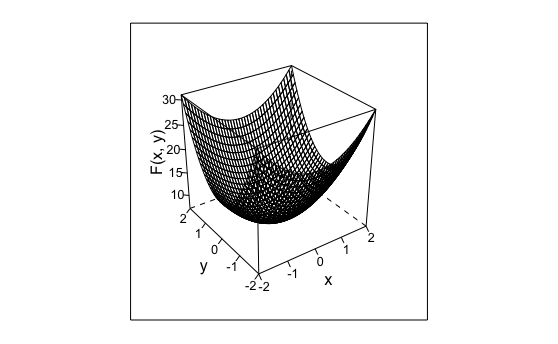

```r
plotFun(F(x,y)~x&y,x.lim=range(-2,2),y.lim=range(-2,2),surface=TRUE)
```

Let’s look at some cross-sections: First with fixed values for $x_{2}$:

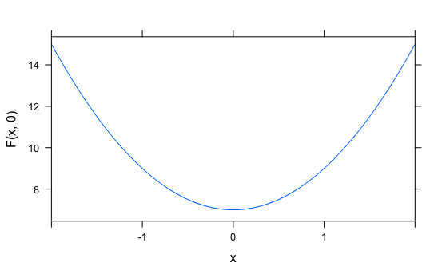

```r
plotFun(F(x,0)~x,x.lim=range(-2,2))
```

Now with fixed values for $x_{1}$:

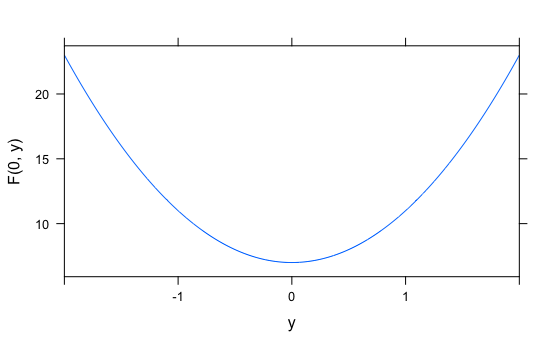

```r
plotFun(F(0,y)~y,y.lim=range(-2,2))
```

Finally, let’s paste the following command into the console to get a contour plot.

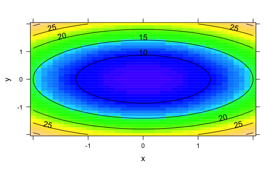

```r
plotFun(F(x,y)~x&y,x.lim=range(-2,2),y.lim=range(-2,2))
```

**Question:** Why does the contour plot look the way it does? Compare and contrast the contour plot of this function with the contour plot of a two-variable linear function.

**Question** Consider the contour plot generated with the following code:

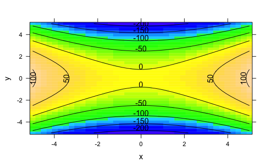

```r
plotFun(4*x^2 - 9*y^2 + 6 ~ x & y,x.lim=range(-5,5),y.lim=range(-5,5))
```

What do you think is the shape of the surface based on the contour plot?